# ML based prediction of quality of exercise

Pallak Goyal

2023-03-27

## Introduction

```r
## training data link
training <- read.csv("./training.csv")
testing <- read.csv("./testing.csv")
```

## Model Building

The database consisted of 19622 observations for 160 variables. However, there was very little measured information available on certain variables. Hence, as a first step the variables having less than 10% of the total measures as NA were identified.Further the variables that were not considered relevant for the purposes of prediction were also dropped from the training data set. The code for the same is given below.

```r
col.details <- data.frame(index=1:160,colname=colnames(training),na.values=rep(NA,160))
for (i in 1:160){
        col.details[i,3] <- sum(is.na(training[,i]))/dim(training)[1]
}
##finding columns to use in analysis
cols.use <- col.details[col.details$na.values<=0.1,1]
##view names of columns to use by na criterion
## doing this so that I can remove some other predictors by logic
col.details[col.details$na.values<=0.1,2]
```

```
##  [1] "X"                       "user_name"
##  [3] "raw_timestamp_part_1"    "raw_timestamp_part_2"
##  [5] "cvtd_timestamp"          "new_window"
##  [7] "num_window"              "roll_belt"
##  [9] "pitch_belt"              "yaw_belt"
## [11] "total_accel_belt"        "kurtosis_roll_belt"
## [13] "kurtosis_picth_belt"     "kurtosis_yaw_belt"
## [15] "skewness_roll_belt"      "skewness_roll_belt.1"
## [17] "skewness_yaw_belt"       "max_yaw_belt"
## [19] "min_yaw_belt"            "amplitude_yaw_belt"
## [21] "gyros_belt_x"            "gyros_belt_y"
## [23] "gyros_belt_z"            "accel_belt_x"
## [25] "accel_belt_y"            "accel_belt_z"
## [27] "magnet_belt_x"           "magnet_belt_y"
## [29] "magnet_belt_z"           "roll_arm"
```

[output cut: 32 more lines]

```r
##relevant to drop user name
cols.use <- cols.use[-2]
##relevant to drop these cols
cols.use <- cols.use[-(1:7)]
training <- training[,cols.use]
training <- training[,-c(5:13,36:41,45:53,67:75)]
```

The training data set was split into training and test set for the purpose of cross-validation.

```r
##splitting data set for cross-validation
library(caret)
inTrain <- createDataPartition(training$classe,p=0.7,list=FALSE)
train.raw <- training[inTrain,]
test.raw <- training[-inTrain,]
```

The Random Forest model was considered the best method. This is because it provides good fit for non-linear models and is highly accurate.The following code was written to fit the model. It optimized the parameters to reduce the run time of the model.

```r
library(caret)
##adjustments to improve speed of model estimation
## set up names to avoid slowness of caret() with model syntax
str(train.raw)
```

```
## 'data.frame':    13737 obs. of  52 variables:
##  $ pitch_belt            : num  8.07 8.05 8.07 8.06 8.09 8.18 8.2 8.21 8.2 8.15 ...
##  $ yaw_belt              : num  -94.4 -94.4 -94.4 -94.4 -94.4 -94.4 -94.4 -94.4 -94.4 -94.4 ...
##  $ total_accel_belt      : int  3 3 3 3 3 3 3 3 3 3 ...
##  $ kurtosis_roll_belt    : chr  "" "" "" "" ...
##  $ gyros_belt_y          : num  0 0 0.02 0 0 0 0 0 0 0 ...
##  $ gyros_belt_z          : num  -0.02 -0.03 -0.02 -0.02 -0.02 -0.02 0 -0.02 0 0 ...
##  $ accel_belt_x          : int  -22 -22 -21 -21 -22 -22 -22 -22 -21 -21 ...
##  $ accel_belt_y          : int  4 3 2 4 3 2 4 4 2 4 ...
##  $ accel_belt_z          : int  22 21 24 21 21 23 21 21 22 23 ...
##  $ magnet_belt_x         : int  -7 -6 -6 0 -4 -2 -3 -8 -1 0 ...
##  $ magnet_belt_y         : int  608 604 600 603 599 602 606 598 597 592 ...
##  $ magnet_belt_z         : int  -311 -310 -302 -312 -311 -319 -309 -310 -310 -305 ...
##  $ roll_arm              : num  -128 -128 -128 -128 -128 -128 -128 -128 -129 -129 ...
##  $ pitch_arm             : num  22.5 22.1 22.1 22 21.9 21.5 21.4 21.4 21.4 21.3 ...
```

[output cut: 38 more lines]

```r
str(test.raw)
```

```
## 'data.frame':    5885 obs. of  52 variables:
##  $ pitch_belt            : num  8.07 8.07 8.13 8.16 8.17 8.18 8.08 8.07 8.1 8.14 ...
##  $ yaw_belt              : num  -94.4 -94.4 -94.4 -94.4 -94.4 -94.4 -94.4 -94.4 -94.4 -94.4 ...
##  $ total_accel_belt      : int  3 3 3 3 3 3 3 3 3 3 ...
##  $ kurtosis_roll_belt    : chr  "" "" "" "" ...
##  $ gyros_belt_y          : num  0 0 0 0 0 0 0.02 0 0 0 ...
##  $ gyros_belt_z          : num  -0.02 -0.02 -0.02 -0.02 0 -0.02 0 -0.02 -0.02 -0.02 ...
##  $ accel_belt_x          : int  -21 -20 -22 -20 -21 -21 -21 -22 -20 -21 ...
##  $ accel_belt_y          : int  4 5 4 2 4 2 5 5 4 3 ...
##  $ accel_belt_z          : int  22 23 21 24 22 23 21 22 22 21 ...
##  $ magnet_belt_x         : int  -3 -2 -2 1 -3 -5 1 -1 -3 -4 ...
##  $ magnet_belt_y         : int  599 600 603 602 609 596 600 604 601 599 ...
##  $ magnet_belt_z         : int  -313 -305 -313 -312 -308 -317 -316 -314 -318 -317 ...
##  $ roll_arm              : num  -128 -128 -128 -128 -128 -128 -129 -129 -129 -129 ...
##  $ pitch_arm             : num  22.5 22.5 21.8 21.7 21.6 21.5 21.2 21.1 20.7 20.7 ...
```

[output cut: 38 more lines]

```r
y <- train.raw[,52]
x <- train.raw[,-52]
library(parallel)
library(doParallel)
cluster <- makeCluster(detectCores() - 1) # convention to leave 1 core for OS
registerDoParallel(cluster)
fitControl <- trainControl(method = "cv",
                           number = 5,
                           allowParallel = TRUE)
modFit <- train(x,y,method="rf",trControl=fitControl)
stopCluster(cluster)
registerDoSEQ()
modFit
```

```
## Random Forest
##
## 13737 samples
##    51 predictor
##     5 classes: 'A', 'B', 'C', 'D', 'E'
##
## No pre-processing
## Resampling: Cross-Validated (5 fold)
## Summary of sample sizes: 10988, 10989, 10990, 10990, 10991
## Resampling results across tuning parameters:
##
##   mtry  Accuracy   Kappa
##    2    0.9911192  0.9887658
##   26    0.9911916  0.9888575
##   51    0.9863144  0.9826869
##
## Accuracy was used to select the optimal model using the largest value.
## The final value used for the model was mtry = 26.
```

```r
modFit$resample
```

```
##    Accuracy     Kappa Resample
## 1 0.9912696 0.9889584    Fold1
## 2 0.9923553 0.9903291    Fold3
## 3 0.9912664 0.9889499    Fold2
## 4 0.9905317 0.9880245    Fold5
## 5 0.9905351 0.9880255    Fold4
```

```r
confusionMatrix.train(modFit)
```

```
## Cross-Validated (5 fold) Confusion Matrix
##
## (entries are percentual average cell counts across resamples)
##
##           Reference
## Prediction    A    B    C    D    E
##          A 28.4  0.2  0.0  0.0  0.0
##          B  0.0 19.0  0.2  0.0  0.0
##          C  0.0  0.1 17.2  0.2  0.0
##          D  0.0  0.0  0.1 16.2  0.1
##          E  0.0  0.0  0.0  0.0 18.3
##
##  Accuracy (average) : 0.9912
```

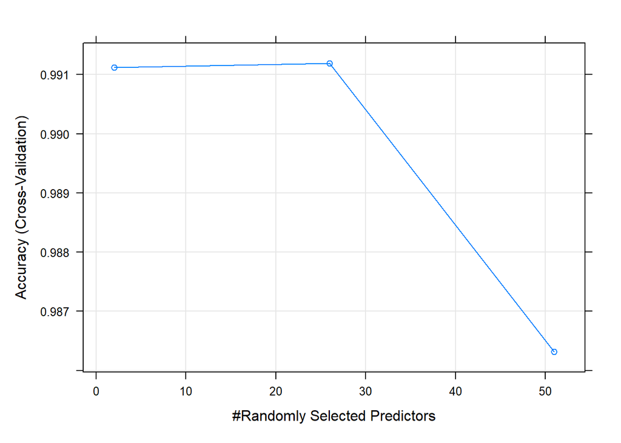

```r
plot(modFit)
```

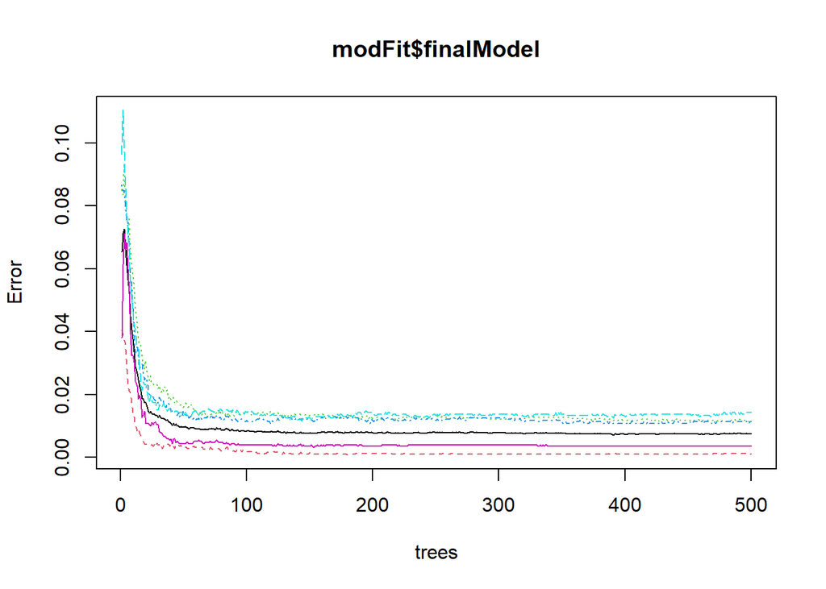

```r
plot(modFit$finalModel)
```

The model was further cross-validated on the test set within the training database.

```r
pdn <- predict(modFit,newdata = test.raw[,-52])
table(pdn)
```

```
## pdn
##    A    B    C    D    E
## 1675 1140 1034  960 1076
```

## Conclusion

The predicted out of sample error is low at 1% as shown above. The model provides a good fit. It is based on the need for accurate predictions. The parameters of the model were not interpreted as that is not an objective of this exercise.